Skip to contents

# Tutorial 4 — Climate Stress-Test Experiment

Hurricane Wind Hazard Model for the Caribbean

2026-04-20

Source: [`vignettes/tutorial_4_stress_test.qmd`](https://github.com/tanerumit/ipdcstorm/blob/main/vignettes/tutorial_4_stress_test.qmd)

## 1. What This Tutorial Covers

This tutorial walks through a **focal-anchored climate stress-test**, mirroring `inst/extcode/05-stress-test-experiment.R`. By the end you will be able to:

- anchor every baseline year with a major historical hurricane drawn from a fixed pool (Irma, Maria, Hugo, Luis, Lenny, Georges) — so you don’t need to roll 10 000 random seasons to sample a rare Cat-4/5 event;
- add a small amount of timing, intensity, and radius jitter to each anchored year so the years are distinct realizations rather than verbatim replays;
- apply **HAZUS-style state-dependent damage** — already-damaged structures are more vulnerable to the next storm;
- pick a handful of high-stress years at fixed quantiles of a 90-day compound damage window at Saba + Statia;
- replay those same years under KNMI’23 warming, keeping the same pinned event and the same jitter so any differences come from the climate signal alone.

```r
library(ipdcstorm)
library(dplyr)
library(ggplot2)
```

## 2. Design Rationale

A random present-day ensemble needs ~10 000 years to sample Cat-4/5 events at Saba / Statia often enough to study the tail. The approach adopted here — **forced anchoring** — guarantees a major event in every year:

1. **Pool.** Six historical Cat-4/5 hurricanes that passed within 300 km of the Saba / Statia midpoint. The pool spans different approach geometries (Irma’s direct Cat-5 hit, Maria south of the islands, Lenny from the west) and intensities (130–155 kt at peak).
2. **Per-year assignment.** Every baseline year gets one pool storm, picked at random. `generate_daily_hazard_impact_spatial()` drops that storm into the hurricane slot for that year; the remaining storms are drawn freely from the climate-adjusted pool.
3. **Stochastic jitter.** The anchored storm is not a carbon copy. A small per-year jitter picks a fresh day-of-year inside the Atlantic hurricane season, scales peak wind by `N(1, 0.05)`, and scales radius by `N(1, 0.05)` — so each year is a distinct “what if Irma hit on August 10 / October 5 / …” case. The ±5 % on intensity and radius reflects real best-track uncertainty for Cat-4/5 storms (Torn and Snyder 2012; Landsea and Franklin 2013) and radius-estimation spread (Vickery and Wadhera 2008).
4. **State-dependent damage.** Each day’s damage rate is nudged up by the damage already accumulated in the same season — the HAZUS-HM progressive-vulnerability idea (Vickery et al. 2006; Pinelli et al. 2004; Grossi and Kunreuther 2005).
5. **Scenario replay.** The five selected years are re-run under KNMI warming scenarios with the **same pinned storm and the same jitter** carried across, so any differences come from the climate signal alone.

## 3. Experiment Configuration

```r
SEED             <- 123
N_BASE           <- 500L                             # raise to 2000+ for production
QUANTILE_PROBS   <- c(0.50, 0.80, 0.90, 0.95, 0.99)
KNMI_SCENARIOS   <- c("knmi_Ld", "knmi_Hd")
TARGET_YEAR      <- 2100                             # 2050 (near-term) or 2100 (end-of-century)

# Compound-stress window (days after focal start) used for selection.
COMPOUND_WINDOW_DAYS <- 90L

# Stochastic pin-jitter configuration (see inst/extcode/05-... for full
# scientific rationale; defaults match the production script).
PIN_TIMING_MODE  <- "uniform_season"
PIN_DOY_MIN      <- 152L            # June 1
PIN_DOY_MAX      <- 304L            # October 31 (leaves 90-d window in year)
PIN_V_SCALE_SD   <- 0.05            # +-5% peak-wind jitter (Torn & Snyder 2012)
PIN_R_SCALE_SD   <- 0.05            # +-5% RMW jitter

# State-dependent damage (HAZUS-HM-style progressive vulnerability).
# d_new(t) = d_raw(t) * (1 + alpha * min(V(t-1), cap))
DAMAGE_ALPHA     <- 3
DAMAGE_V_CAP     <- 0.5

# Pool of historical major hurricanes (Cat-4+ within ~300 km of Saba/Statia).
PINNED_SID_POOL <- c(
  "2017242N16333",   # Irma     (2017) - Cat-5 direct hit
  "2017260N12310",   # Maria    (2017) - Cat-5 passing south
  "1989254N13340",   # Hugo     (1989) - Cat-4 reference
  "1995241N11333",   # Luis     (1995) - St Martin landfall
  "1999318N17278",   # Lenny    (1999) - unusual east-bound November Cat-4
  "1998259N10335"    # Georges  (1998) - closest Cat-4 approach
)

targets <- tibble::tribble(
  ~name,         ~lat,     ~lon,
  "St_Martin",   18.0708, -63.0501,
  "Saba",        17.6350, -63.2300,
  "Statia",      17.4890, -62.9740
)

DATA_PATH <- system.file("extdata", "ibtracs_1970.csv", package = "ipdcstorm")
```

### 3.1. Pool selection

The six pool SIDs were chosen by filtering IBTrACS (Knapp et al. 2010, 2018) for storms that reached Cat-4+ at some point in their life **and** passed within 300 km of the Saba / Statia midpoint. Swap in different SIDs to stress-test different geometries — any SID in the IBTrACS input works. Full impact summaries with NHC Tropical Cyclone Report citations are in `dev/storm-pool-reference.md`.

| SID | Name | Year | Peak wind (kt) | Min pres (hPa) | Saffir–Simpson | Min dist to Saba (km) | Character | Reference |
| --- | --- | --- | --- | --- | --- | --- | --- | --- |
| 2017242N16333 | **Irma** | 2017 | 155 | 914 | Cat 5 | 52 | Cat-5 direct hit on Sint Maarten (6 km); ~US$2.5 B Dutch-side loss | Cangialosi, Latto, and Berg (2018); Government of Sint Maarten (2018) |
| 2017260N12310 | **Maria** | 2017 | 150 | 908 | Cat 5 | 117 | Cat-5 passing ~115 km south; compounding effect on Irma-damaged stock | Pasch, Penny, and Berg (2019) |
| 1989254N13340 | **Hugo** | 1989 | 140 | 918 | Cat 5 | 87 | Cat-4 reference; 11 fatalities / ~US$50 M across Netherlands Antilles | Case and Mayfield (1990) |
| 1995241N11333 | **Luis** | 1995 | 130 | 935 | Cat 4 | 84 | Cat-4 southern eyewall on SXM; ~US$1.8 B Dutch-side loss | Lawrence (1996); Economic Commission for Latin America and the Caribbean (1996) |
| 1999318N17278 | **Lenny** | 1999 | 135 | 933 | Cat 4 | 41 | Unusual west-to-east November track; west-coast surge on SXM | Guiney (2000); Economic Commission for Latin America and the Caribbean (2000) |
| 1998259N10335 | **Georges** | 1998 | 135 | 937 | Cat 4 | 47 | Closest Cat-4 eye approach to Statia (33 km); minor Dutch-Caribbean damage | Guiney (1999) |

Distances are great-circle minimums between each storm’s IBTrACS track and Saba; intensity figures are lifetime peaks (generally larger than site-level wind felt on the islands).

## 4. Anchored Baseline

### 4.1. Build the pin map and jitter map

Two internal helpers do the bookkeeping. They live in `R/stress_test_helpers.R` and use the dot-prefix convention (not exported from the package), so user scripts call them through the `:::` operator.

```r
# One SID per sim_year, sampled uniformly from the pool with replacement.
baseline_pin_map <- ipdcstorm:::.build_pin_map(
  sim_years = seq_len(N_BASE),
  pool      = PINNED_SID_POOL,
  seed      = SEED
)

# One jitter spec per sim_year. In "uniform_season" mode the focal day-of-year
# is drawn uniformly from [PIN_DOY_MIN, PIN_DOY_MAX], discarding each SID's
# historical date.
baseline_pin_jitter <- ipdcstorm:::.build_pin_jitter(
  sim_years  = seq_len(N_BASE),
  mode       = PIN_TIMING_MODE,
  doy_min    = PIN_DOY_MIN,
  doy_max    = PIN_DOY_MAX,
  v_scale_sd = PIN_V_SCALE_SD,
  r_scale_sd = PIN_R_SCALE_SD,
  seed       = SEED + 1L
)

head(baseline_pin_jitter, 3)
```

```
#> $`1`
#> $`1`$doy_offset
#> [1] NA
#>
#> $`1`$doy_abs
#> [1] 164
#>
#> $`1`$v_scale
#> [1] 1.024708
#>
#> $`1`$r_scale
#> [1] 1.047525
#>
#>
#> $`2`
#> $`2`$doy_offset
#> [1] NA
#>
#> $`2`$doy_abs
#> [1] 214
#>
#> $`2`$v_scale
#> [1] 0.958459
#>
#> $`2`$r_scale
#> [1] 0.9108607
#>
#>
#> $`3`
#> $`3`$doy_offset
#> [1] NA
#>
#> $`3`$doy_abs
#> [1] 230
#>
#> $`3`$v_scale
#> [1] 1.040399
#>
#> $`3`$r_scale
#> [1] 0.8752162
```

Each entry is a small list: `doy_offset` (unused in uniform-season mode), `doy_abs` (the sampled day-of-year that overrides the historical date), `v_scale` (peak-wind multiplier), and `r_scale` (radius multiplier).

### 4.2. Run the stationary baseline

```r
bg_cfg <- ipdcstorm:::.make_stress_test_background_wind_cfg()

cfg_base <- make_hazard_cfg(
  data_path        = DATA_PATH,
  simulation_years = N_BASE,
  climate          = make_climate_cfg(scenario = "stationary"),
  background_wind  = bg_cfg
)

out_base <- run_hazard_model(cfg_base, targets = targets,
                             seed = SEED, verbose = FALSE)
```

### 4.3. Generate daily hazard with pinned focal events

Pass `pinned_sids` and `pin_jitter` to the daily generator. The jitter is applied **before** any climate warming, so internal variability and climate forcing stack cleanly.

```r
daily_base_list <- generate_daily_hazard_impact_spatial(
  out         = out_base,
  location    = targets$name,
  sim_years   = seq_len(N_BASE),
  year0       = 2000L,
  gust_factor = 1.0,
  damage      = list(method = "intensity"),
  pulse_shape = "cosine",
  scenario    = "baseline",
  seed        = SEED,
  pinned_sids = baseline_pin_map,
  pin_jitter  = baseline_pin_jitter
)
```

### 4.4. Apply state-dependent damage amplification

Post-process the daily output so each day’s damage is bumped up by whatever damage has already accumulated in the same year. Damaged structures have less capacity left; the next storm’s wind does more harm. This is a simplified HAZUS-HM progressive-vulnerability model (Vickery et al. 2006; Pinelli et al. 2004).

```r
daily_base_list <- ipdcstorm:::.apply_state_dependent_damage(
  daily_list = daily_base_list,
  alpha      = DAMAGE_ALPHA,
  cap        = DAMAGE_V_CAP
)
```

The helper keeps the original numbers in a new `damage_rate_raw` column and overwrites `damage_rate` / `cum_damage` with the amplified values.

### 4.5. Verify every pin landed

```r
missed <- ipdcstorm:::.verify_pins_landed(daily_base_list, baseline_pin_map)
nrow(missed)
```

```
#> [1] 0
```

`.verify_pins_landed()` returns the rows where the pinned storm failed to appear — usually only happens in years where the rate draw produced zero hurricanes and the insertion logic couldn’t add one. At the historical baseline rate, expect zero misses.

## 5. Quantile Selection

### 5.1. Compound-stress metric

`compute_compound_stress_year_metrics()` finds each year’s strongest event at the target locations and totals the damage over a window of `COMPOUND_WINDOW_DAYS` starting when the focal event begins.

```r
compound_metrics <- ipdcstorm:::compute_compound_stress_year_metrics(
  daily       = daily_base_list,
  sim_years   = seq_len(N_BASE),
  location    = c("Saba", "Statia"),
  window_days = COMPOUND_WINDOW_DAYS
)

head(compound_metrics, 3)
```

```
#> # A tibble: 3 × 10
#>   sim_year focal_event_id       focal_start_doy focal_end_doy focal_peak_wind_kt
#>      <int> <chr>                          <int>         <int>              <dbl>
#> 1        1 1989254N13340_y2000…             164           167               54.2
#> 2        2 1998259N10335_y2001…             214           216               95.8
#> 3        3 1996187N10326_y2002…             189           191               73
#> # ℹ 5 more variables: compound_window_end_doy <int>, compound_n_events <int>,
#> #   compound_n_aftermath_events <int>, compound_cum_damage <dbl>,
#> #   compound_max_damage_rate <dbl>
```

Key columns:

- `focal_event_id` — the strongest event at Saba or Statia;
- `focal_start_doy` / `focal_end_doy` — the focal event’s first and last day (as day-of-year);
- `focal_peak_wind_kt` — peak wind at those sites during that event;
- `compound_cum_damage` — combined Saba + Statia damage across the 90-day window;
- `compound_n_aftermath_events` — how many separate follow-on storms happen in that window.

### 5.2. Rank candidates and pick quantile years

Rank primarily by compound damage; break ties with the year’s total annual damage. This keeps Lenny-anchored late-season years (which often have no follow-on inside the window) from collapsing onto each other.

```r
sim_counts <- out_base$sim |>
  filter(location == targets$name[1]) |>
  select(sim_year, n_total)

annual_damage <- dplyr::bind_rows(
  daily_base_list[["Saba"]], daily_base_list[["Statia"]]
) |>
  dplyr::group_by(sim_year) |>
  dplyr::summarise(annual_total_damage = sum(damage_rate, na.rm = TRUE),
                   .groups = "drop")

year_metrics <- compound_metrics |>
  left_join(sim_counts,    by = "sim_year") |>
  left_join(annual_damage, by = "sim_year")

n_cand <- nrow(year_metrics)

compound_rated <- year_metrics |>
  arrange(compound_cum_damage, annual_total_damage) |>
  mutate(rating = seq_len(dplyr::n()) / n_cand)

sel_pos      <- pmax(1L, ceiling(QUANTILE_PROBS * n_cand))
selected_ids <- compound_rated$sim_year[sel_pos]

focal_sids <- baseline_pin_map[as.character(selected_ids)]

compound_rated |>
  filter(sim_year %in% selected_ids) |>
  mutate(quantile = paste0("Q", round(QUANTILE_PROBS * 100))) |>
  select(quantile, sim_year, focal_peak_wind_kt,
         compound_n_aftermath_events, compound_cum_damage,
         annual_total_damage)
```

```
#> # A tibble: 5 × 6
#>   quantile sim_year focal_peak_wind_kt compound_n_aftermath_events
#>   <chr>       <int>              <dbl>                       <int>
#> 1 Q50           172               64.8                           1
#> 2 Q80           479              104.                            2
#> 3 Q90            49              116.                            1
#> 4 Q95            22              120.                            0
#> 5 Q99           201              124.                            1
#> # ℹ 2 more variables: compound_cum_damage <dbl>, annual_total_damage <dbl>
```

## 6. KNMI’23 Replays

Replay the five selected years under each KNMI’23 scenario (KNMI 2023). The **same pin map** and the **same jitter** are passed through, so the focal event lands on the same day with the same intensity and radius in every run. The only thing that changes across scenarios is the warming value `delta_sst` — applied on top of the jitter by `perturb_event()`, which scales the Holland parametric wind profile (Holland 1980).

```r
cc_stress <- vector("list", length(KNMI_SCENARIOS))
names(cc_stress) <- KNMI_SCENARIOS

replay_pins <- stats::setNames(
  focal_sids[as.character(selected_ids)],
  as.character(seq_along(selected_ids))
)
replay_jitter <- stats::setNames(
  baseline_pin_jitter[as.character(selected_ids)],
  as.character(seq_along(selected_ids))
)
n_selected <- length(selected_ids)

for (scen in KNMI_SCENARIOS) {
  cfg_cc <- make_hazard_cfg(
    data_path        = DATA_PATH,
    simulation_years = n_selected,
    climate          = make_climate_cfg(scenario    = scen,
                                        target_year = TARGET_YEAR,
                                        perturb     = TRUE),
    background_wind  = bg_cfg
  )
  out_cc <- run_hazard_model(cfg_cc, targets = targets,
                             seed = SEED, verbose = FALSE)

  cc_daily <- generate_daily_hazard_impact_spatial(
    out         = out_cc,
    location    = targets$name,
    sim_years   = seq_len(n_selected),
    year0       = 2000L,
    gust_factor = 1.0,
    damage      = list(method = "intensity"),
    pulse_shape = "cosine",
    scenario    = scen,
    seed        = SEED,
    pinned_sids = replay_pins,
    pin_jitter  = replay_jitter
  )

  # Remap replay slot 1..n_selected back onto baseline sim_year IDs, then
  # apply the same state-dependent damage amplification used for baseline.
  cc_daily <- ipdcstorm:::.remap_replay_years(
    daily_list   = cc_daily,
    baseline_ids = selected_ids
  )
  cc_daily <- ipdcstorm:::.apply_state_dependent_damage(
    daily_list = cc_daily,
    alpha      = DAMAGE_ALPHA,
    cap        = DAMAGE_V_CAP
  )

  cc_stress[[scen]] <- cc_daily
}

baseline_stress <- lapply(daily_base_list, function(df) {
  df[df$sim_year %in% selected_ids, ]
})
```

## 7. Visualise the Stress-Test Traces

Build one long tibble with all three scenarios, filter to the selected years, and facet by year.

```r
daily_by_scen <- list(
  baseline = baseline_stress,
  knmi_Ld  = cc_stress[["knmi_Ld"]],
  knmi_Hd  = cc_stress[["knmi_Hd"]]
)

year_labels <- setNames(
  paste0("Q", round(QUANTILE_PROBS * 100), " (year ", selected_ids, ")"),
  as.character(selected_ids)
)

focal_location <- "Saba"

long_loc <- dplyr::bind_rows(lapply(names(daily_by_scen), function(scen) {
  df <- daily_by_scen[[scen]][[focal_location]]
  df$scenario <- scen
  df
}))
long_loc <- long_loc[long_loc$sim_year %in% selected_ids, , drop = FALSE]
long_loc$year_label <- factor(
  year_labels[as.character(long_loc$sim_year)],
  levels = year_labels
)
```

### 7.1. Daily wind with TS / HUR thresholds

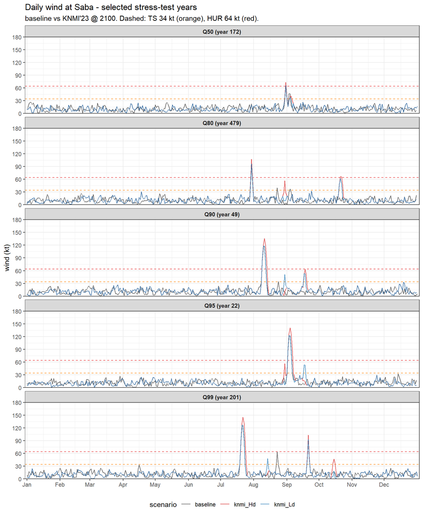

```r
scen_colours <- c(baseline = "#444444",
                  knmi_Ld  = "#1f77b4",
                  knmi_Hd  = "#d62728")

doy_month_breaks <- c(1, 32, 60, 91, 121, 152, 182, 213, 244, 274, 305, 335)
doy_month_labels <- month.abb

ggplot(long_loc, aes(doy, wind_kt, colour = scenario)) +
  geom_hline(yintercept = 34, linetype = "dashed",
             colour = "#ff7f00", linewidth = 0.5, alpha = 0.8) +
  geom_hline(yintercept = 64, linetype = "dashed",
             colour = "#e31a1c", linewidth = 0.5, alpha = 0.8) +
  geom_line(linewidth = 0.5, alpha = 0.85) +
  facet_wrap(~ year_label, ncol = 1) +
  scale_colour_manual(values = scen_colours) +
  scale_x_continuous(
    breaks = doy_month_breaks, labels = doy_month_labels,
    limits = c(1, 366), expand = c(0.005, 0)
  ) +
  scale_y_continuous(limits = c(0, 180), breaks = seq(0, 180, by = 30),
                     expand = c(0, 0)) +
  labs(
    title = paste0("Daily wind at ", focal_location,
                   " - selected stress-test years"),
    subtitle = paste0("baseline vs KNMI'23 @ ", TARGET_YEAR,
                      ". Dashed: TS 34 kt (orange), HUR 64 kt (red)."),
    x = NULL, y = "wind (kt)", colour = "scenario"
  ) +
  theme_bw(base_size = 11) +
  theme(legend.position = "bottom",
        strip.text = element_text(face = "bold"))
```

## 8. Baseline Stress Distribution

Rank-ordered view of the full baseline’s compound damage, coloured by which storm was pinned. The five selected quantile years appear as labelled markers against the cloud of all 500 anchored years. The visible plateaus are each pool storm’s characteristic damage signature; within-plateau spread comes from jitter, state-dependent amplification, and non-focal follow-on storms.

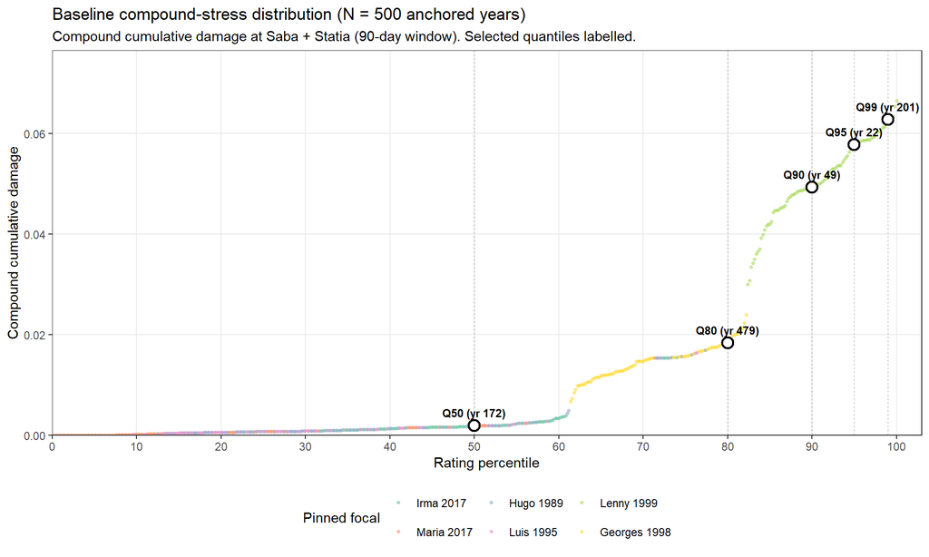

```r
PINNED_SID_NAMES <- c(
  "2017242N16333" = "Irma 2017",   "2017260N12310" = "Maria 2017",
  "1989254N13340" = "Hugo 1989",   "1995241N11333" = "Luis 1995",
  "1999318N17278" = "Lenny 1999",  "1998259N10335" = "Georges 1998"
)

rank_dist <- compound_rated |>
  mutate(
    rank_pct   = 100 * rating,
    pinned_sid = unname(unlist(baseline_pin_map[as.character(sim_year)])),
    pinned     = factor(PINNED_SID_NAMES[pinned_sid],
                        levels = PINNED_SID_NAMES[PINNED_SID_POOL])
  )

selected_rows <- rank_dist |>
  filter(sim_year %in% selected_ids) |>
  mutate(
    qlab = paste0("Q", round(QUANTILE_PROBS[match(sim_year, selected_ids)] * 100)),
    plab = paste0(qlab, " (yr ", sim_year, ")")
  )

ggplot(rank_dist, aes(rank_pct, compound_cum_damage)) +
  geom_vline(data = selected_rows, aes(xintercept = rank_pct),
             linetype = "dashed", colour = "grey40",
             linewidth = 0.3, alpha = 0.6) +
  geom_point(aes(colour = pinned), size = 0.9, alpha = 0.55) +
  geom_point(data = selected_rows, shape = 21, fill = "white",
             colour = "black", size = 3.5, stroke = 1.1) +
  geom_text(data = selected_rows, aes(label = plab),
            vjust = -1.0, size = 3, fontface = "bold") +
  scale_colour_brewer(palette = "Set2", name = "Pinned focal") +
  scale_x_continuous(breaks = seq(0, 100, 10),
                     limits = c(0, 103), expand = c(0, 0)) +
  scale_y_continuous(
    limits = c(0, max(rank_dist$compound_cum_damage, na.rm = TRUE) * 1.15),
    expand = c(0, 0)
  ) +
  labs(
    title = paste0("Baseline compound-stress distribution (N = ",
                   N_BASE, " anchored years)"),
    subtitle = paste0("Compound cumulative damage at Saba + Statia (",
                      COMPOUND_WINDOW_DAYS,
                      "-day window). Selected quantiles labelled."),
    x = "Rating percentile",
    y = "Compound cumulative damage"
  ) +
  theme_bw(base_size = 11) +
  theme(legend.position = "bottom",
        panel.grid.minor = element_blank())
```

Cangialosi, John P., Andrew S. Latto, and Robbie Berg. 2018. “Tropical Cyclone Report: Hurricane Irma (30 August – 12 September 2017).” AL112017. NOAA National Hurricane Center. https://www.nhc.noaa.gov/data/tcr/AL112017_Irma.pdf.

Case, Bob, and Max Mayfield. 1990. “Preliminary Report: Hurricane Hugo (10 – 22 September 1989).” NOAA National Hurricane Center. https://www.weather.gov/media/ilm/climate/Hugo/NHC_report_Hugo.pdf.

Economic Commission for Latin America and the Caribbean. 1996. “St. Kitts and Nevis, Anguilla, Sint Maarten: Effects of Hurricane Luis.” ECLAC / CEPAL. https://www.cepal.org/en/publications/25592-st-kitts-nevis-anguilla-sint-maarten-effects-hurricane-luis.

———. 2000. “Saint Kitts and Nevis, Antigua and Barbuda, Netherlands Antilles: Effects of Hurricane Lenny.” ECLAC / CEPAL. https://www.cepal.org/en/publications/25548-saint-kitts-nevis-antigua-barbuda-netherlands-antilles-effects-hurricane-lenny.

Government of Sint Maarten. 2018. “Sint Maarten National Recovery and Resilience Plan.” Government of Sint Maarten. https://www.government.sx/Portals/0/Recovery%20Plan/NRRP_final.pdf.

Grossi, Patricia, and Howard Kunreuther. 2005. *Catastrophe Modeling: A New Approach to Managing Risk*. Boston, MA: Springer.

Guiney, John L. 1999. “Preliminary Report: Hurricane Georges (15 September – 1 October 1998).” AL071998. NOAA National Hurricane Center. https://www.nhc.noaa.gov/data/tcr/AL071998_Georges.pdf.

———. 2000. “Preliminary Report: Hurricane Lenny (13 – 23 November 1999).” AL161999. NOAA National Hurricane Center. https://www.nhc.noaa.gov/data/tcr/AL161999_Lenny.pdf.

Holland, Greg J. 1980. “An Analytic Model of the Wind and Pressure Profiles in Hurricanes.” *Monthly Weather Review* 108 (8): 1212–18. https://doi.org/10.1175/1520-0493(1980)108<1212:AAMOTW>2.0.CO;2.

Knapp, Kenneth R., Howard J. Diamond, James P. Kossin, Michael C. Kruk, and Carl J. Schreck. 2018. “International Best Track Archive for Climate Stewardship (IBTrACS) Project, Version 4.” NOAA National Centers for Environmental Information. https://doi.org/10.25921/82ty-9e16.

Knapp, Kenneth R., Michael C. Kruk, David H. Levinson, Howard J. Diamond, and Charles J. Neumann. 2010. “The International Best Track Archive for Climate Stewardship (IBTrACS): Unifying Tropical Cyclone Data.” *Bulletin of the American Meteorological Society* 91 (3): 363–76. https://doi.org/10.1175/2009BAMS2755.1.

KNMI. 2023. “KNMI’23 Climate Scenarios for the Netherlands.” Royal Netherlands Meteorological Institute. https://www.knmi.nl/klimaatscenarios.

Landsea, Christopher W., and James L. Franklin. 2013. “Atlantic Hurricane Database Uncertainty and Presentation of a New Database Format.” *Monthly Weather Review* 141 (10): 3576–92. https://doi.org/10.1175/MWR-D-12-00254.1.

Lawrence, Miles B. 1996. “Preliminary Report: Hurricane Luis (27 August – 11 September 1995).” AL131995. NOAA National Hurricane Center. https://www.nhc.noaa.gov/data/tcr/AL131995_Luis.pdf.

Pasch, Richard J., Andrew B. Penny, and Robbie Berg. 2019. “Tropical Cyclone Report: Hurricane Maria (16 – 30 September 2017).” AL152017. NOAA National Hurricane Center. https://www.nhc.noaa.gov/data/tcr/AL152017_Maria.pdf.

Pinelli, Jean-Paul, Emil Simiu, Kurt Gurley, Chelakara Subramanian, Liang Zhang, Anne Cope, James J. Filliben, and Shahid Hamid. 2004. “Hurricane Damage Prediction Model for Residential Structures.” *Journal of Structural Engineering* 130 (11): 1685–91. https://doi.org/10.1061/(ASCE)0733-9445(2004)130:11(1685).

Torn, Ryan D., and Chris Snyder. 2012. “Uncertainty of Tropical Cyclone Best-Track Information.” *Weather and Forecasting* 27 (3): 715–29. https://doi.org/10.1175/WAF-D-11-00085.1.

Vickery, Peter J., Peter F. Skerlj, Jason Lin, Lawrence A. Twisdale, Michael A. Young, and Francis M. Lavelle. 2006. “HAZUS-MH Hurricane Model Methodology.” Applied Research Associates / FEMA.

Vickery, Peter J., and Dhiraj Wadhera. 2008. “Statistical Models of Holland Pressure Profile Parameter and Radius to Maximum Winds of Hurricanes from Flight-Level Pressure and H*Wind Data.” *Journal of Applied Meteorology and Climatology* 47 (10): 2497–517. https://doi.org/10.1175/2008JAMC1837.1.